# codigo_anova

gjh

2026-06-21

## R Markdown

### Codigo del proyecto

##Instalacion de algunas cosas

```r
#install.packages("pwr")
library(pwr)
```

## Importacion del archivo

```r
library(readr)
datos <- read_delim("datos.csv", delim=";")  #usar esta funcion para leer ;
#conversion a factores
datos$bloque<-factor(datos$bloque)
datos$harina<-factor(datos$harina)
datos$fermentador<-factor(datos$fermentador)
```

## Algunos analisis descriptivos

medias generales

```r
media_general <- mean(datos$incremento)
media_general
```

```
## [1] 1.49
```

```r
media_bloque <-tapply(datos$incremento, datos$bloque, mean)
media_bloque
```

```
##   bloque1   bloque2   bloque3   bloque4   bloque5
## 1.8333333 1.5000000 1.4666667 1.6666667 0.9833333
```

medias por tratamiento

```r
aggregate(incremento ~ harina + fermentador,
          data = datos,
          mean)
```

```
##     harina   fermentador incremento
## 1 integral azucar blanca       1.38
## 2    trigo azucar blanca       1.28
## 3 integral  azucar cruda       1.58
## 4    trigo  azucar cruda       1.70
## 5 integral          miel       1.24
## 6    trigo          miel       1.76
```

```r
library(dplyr)
```

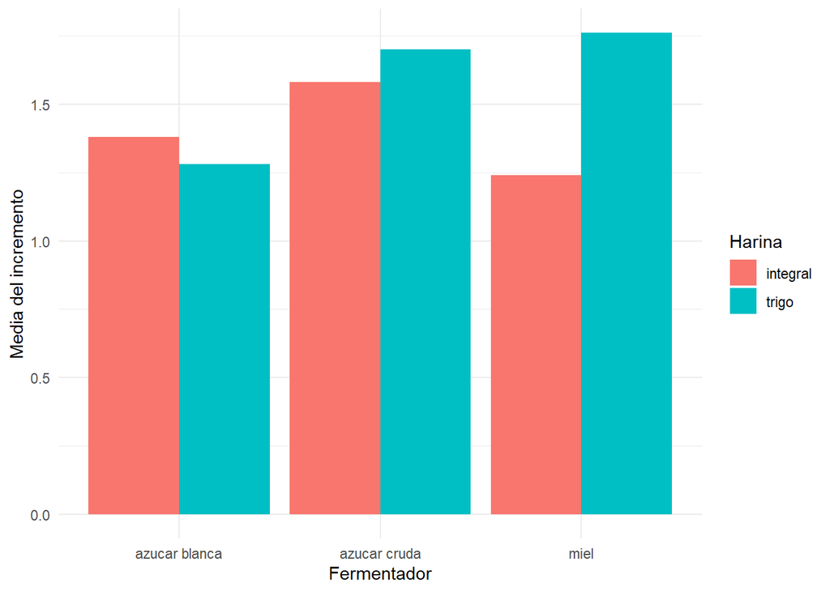

```r
library(ggplot2)

medias <- datos %>%
  group_by(harina, fermentador) %>%
  summarise(media = mean(incremento), .groups = "drop")

ggplot(medias,
       aes(x = fermentador,
           y = media,
           fill = harina)) +
  geom_col(position = "dodge") +
  labs(x = "Fermentador",
       y = "Media del incremento",
       fill = "Harina") +
  theme_minimal()
```

coeficiente de variacion

```r
cv <- sd(datos$incremento) / mean(datos$incremento) * 100
cv
```

```
## [1] 29.87689
```

Resumen

```r
summary(datos$incremento)
```

```
##    Min. 1st Qu.  Median    Mean 3rd Qu.    Max.
##   0.700   1.125   1.450   1.490   1.700   2.400
```

## Modelo lineal con interaccion

```r
modelo1 <- lm(incremento~bloque+harina*fermentador, data = datos)
```

Se ajusta a un modelo lineal con interaccion y se lee como : variable incremento explicada por el efecto de la harina + fermentador y la interacción.

## Comprobación de los supuestos del modelo con interacción

```r
#extraccion de los residuales
residuales<-modelo1$residuals
#supuesto de normalidad
shapiro.test(residuales)
```

```
##
##  Shapiro-Wilk normality test
##
## data:  residuales
## W = 0.94046, p-value = 0.0936
```

La normalidad de los residuos se evaluo, mediante Shapiro-Wilk, con resultados W = 0.94046, p-value = 0.0936 los cuales indican que que no se eontraron desviaciones significativas de la normalidad, por lo que se considera que el supuesto se cumple y no se rechaza la hipotesis nula.

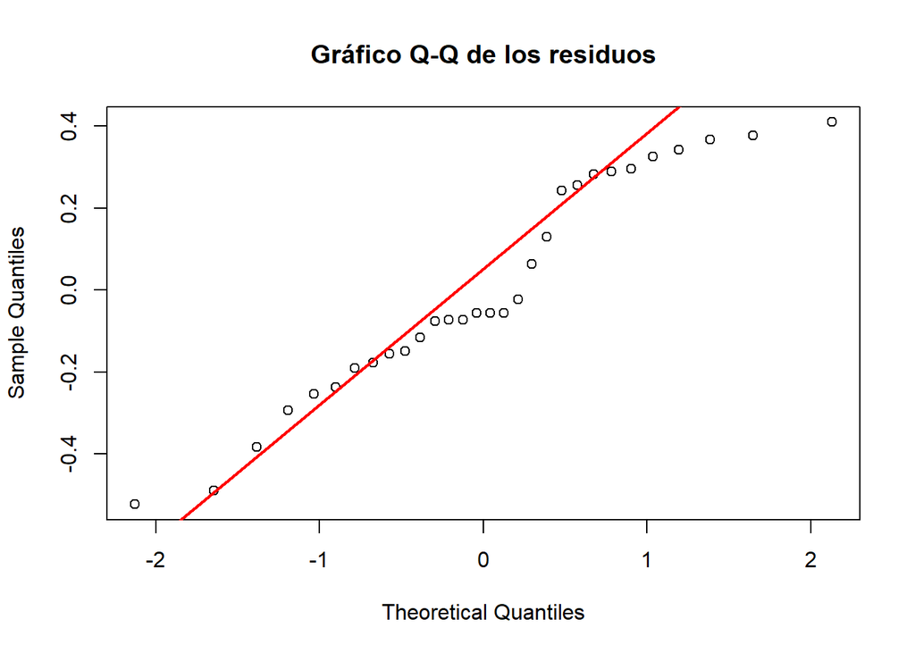

```r
qqnorm(residuals(modelo1),
       main = "Gráfico Q-Q de los residuos")
qqline(residuals(modelo1),
       col = "red",
       lwd = 2)
```

```r
#supuesto de homocedasticidad
bartlett.test(residuals(modelo1)~interaction(datos$harina, datos$fermentador), data = datos)
```

```
##
##  Bartlett test of homogeneity of variances
##
## data:  residuals(modelo1) by interaction(datos$harina, datos$fermentador)
## Bartlett's K-squared = 1.8654, df = 5, p-value = 0.8674
```

NO se rechaza la hipotesis de homocedasticidad, por lo tanto, se puede asumir que las varianzas de la variable respuesta dentro de cada tratamiento son iguales.

## Analisis de varianza general

```r
coeficientesmodelo1 <-modelo1$coefficients
coeficientesmodelo1
```

```
##                         (Intercept)                       bloquebloque2
##                           1.7233333                          -0.3333333
##                       bloquebloque3                       bloquebloque4
##                          -0.3666667                          -0.1666667
##                       bloquebloque5                         harinatrigo
##                          -0.8500000                          -0.1000000
##             fermentadorazucar cruda                     fermentadormiel
##                           0.2000000                          -0.1400000
## harinatrigo:fermentadorazucar cruda         harinatrigo:fermentadormiel
##                           0.2200000                           0.6200000
```

```r
anova(modelo1)
```

```
## Analysis of Variance Table
##
## Response: incremento
##                    Df Sum Sq Mean Sq F value   Pr(>F)
## bloque              4 2.4387 0.60967  5.8360 0.002794 **
## harina              1 0.2430 0.24300  2.3261 0.142879
## fermentador         2 0.4820 0.24100  2.3070 0.125457
## harina:fermentador  2 0.4940 0.24700  2.3644 0.119749
## Residuals          20 2.0893 0.10447
## ---
## Signif. codes:  0 '***' 0.001 '**' 0.01 '*' 0.05 '.' 0.1 ' ' 1
```

## Modelo sin interación

```r
modelo2 = lm (incremento ~ bloque+harina+fermentador, data = datos)
```

## Graficos de cajas con bloques y centrados

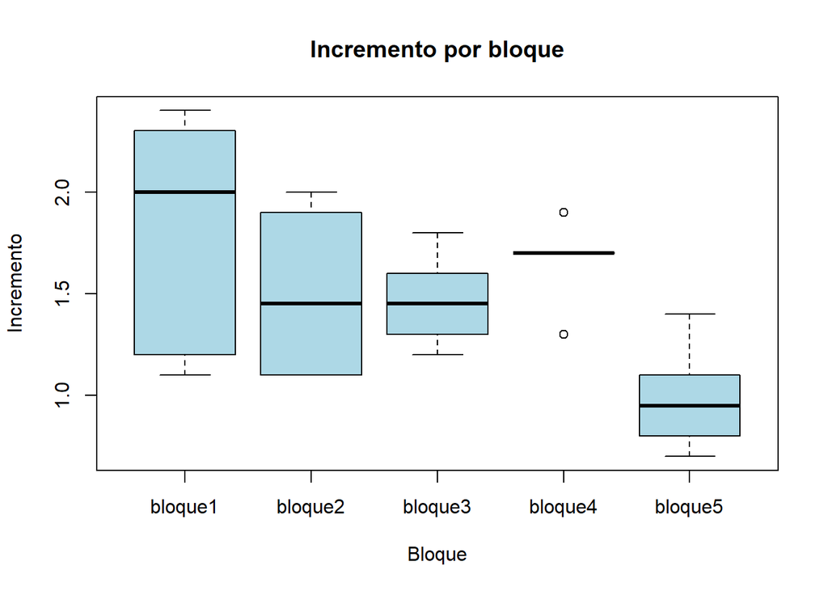

```r
boxplot(incremento ~ bloque,
        data = datos,
        col = "lightblue",
        main = "Incremento por bloque",
        xlab = "Bloque",
        ylab = "Incremento")
```

```r
media.general <- mean(datos$incremento)

datos$incremento.centrado <- with(
  datos,
  incremento - ave(incremento, bloque, FUN = mean) + media.general
)
```

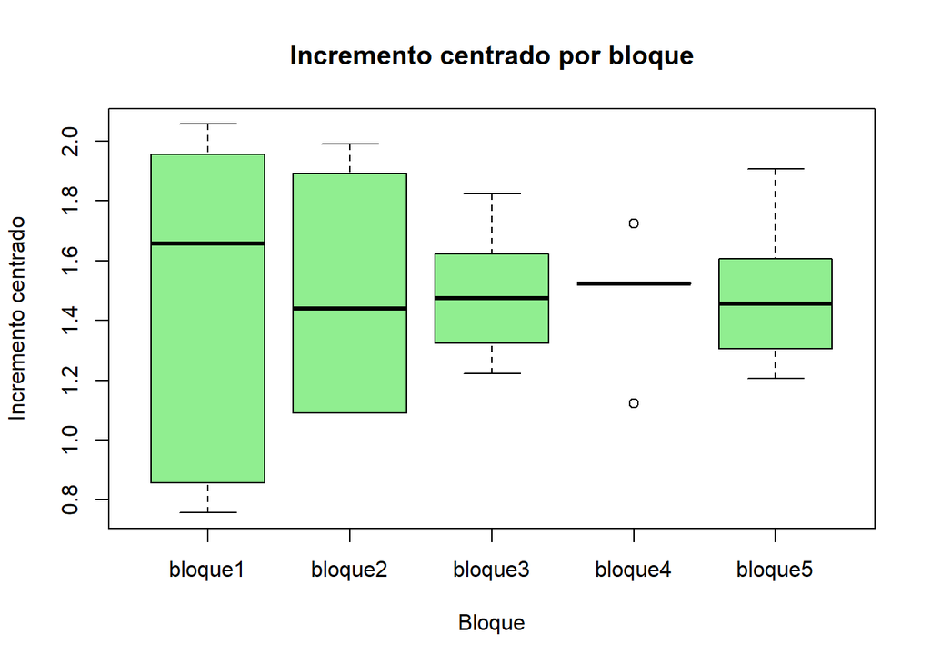

```r
boxplot(incremento.centrado ~ bloque,
        data = datos,
        col = "lightgreen",
        main = "Incremento centrado por bloque",
        xlab = "Bloque",
        ylab = "Incremento centrado")
```

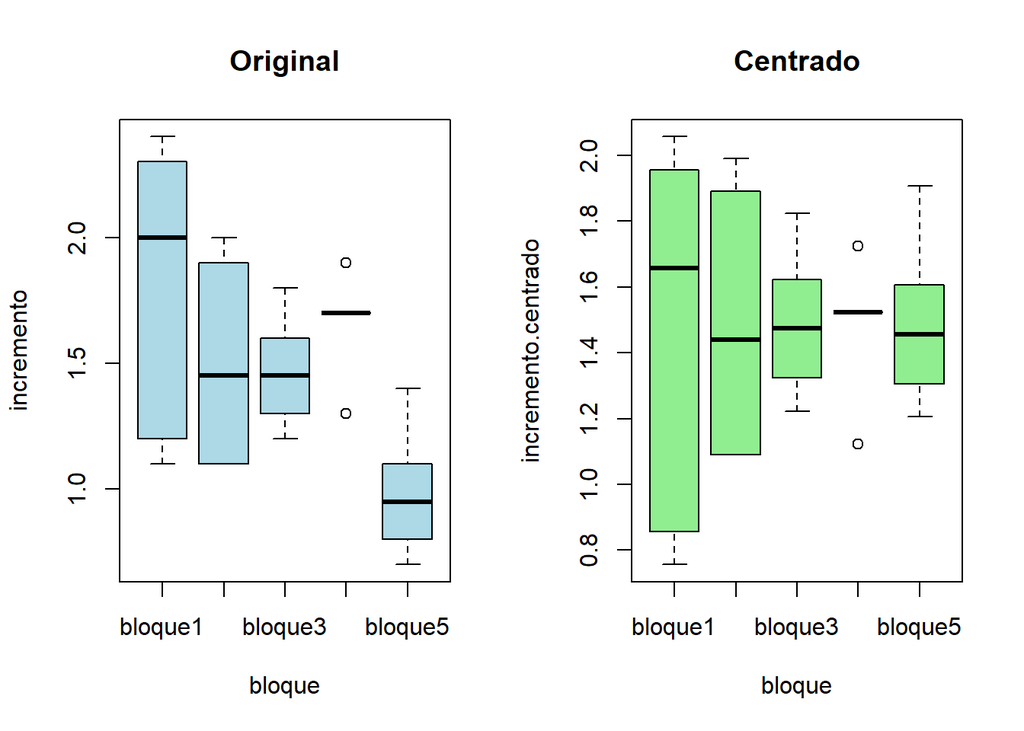

```r
par(mfrow = c(1,2))

boxplot(incremento ~ bloque,
        data = datos,
        col = "lightblue",
        main = "Original")

boxplot(incremento.centrado ~ bloque,
        data = datos,
        col = "lightgreen",
        main = "Centrado")
```

## Comprobacion de los supuestos

```r
#supuesto de normalidad
residuales2<- modelo2$residuals
shapiro.test(residuales2)
```

```
##
##  Shapiro-Wilk normality test
##
## data:  residuales2
## W = 0.97574, p-value = 0.7045
```

La normalidad de los residuos se evaluo, mediante Shapiro-Wilk, con resultados W = 0.97574, p-value = 0.7045 los cuales indican que que no se econtraron desviaciones significativas de la normalidad, por lo que se considera que el supuesto se cumple y no se rechaza la hipotesis nula.

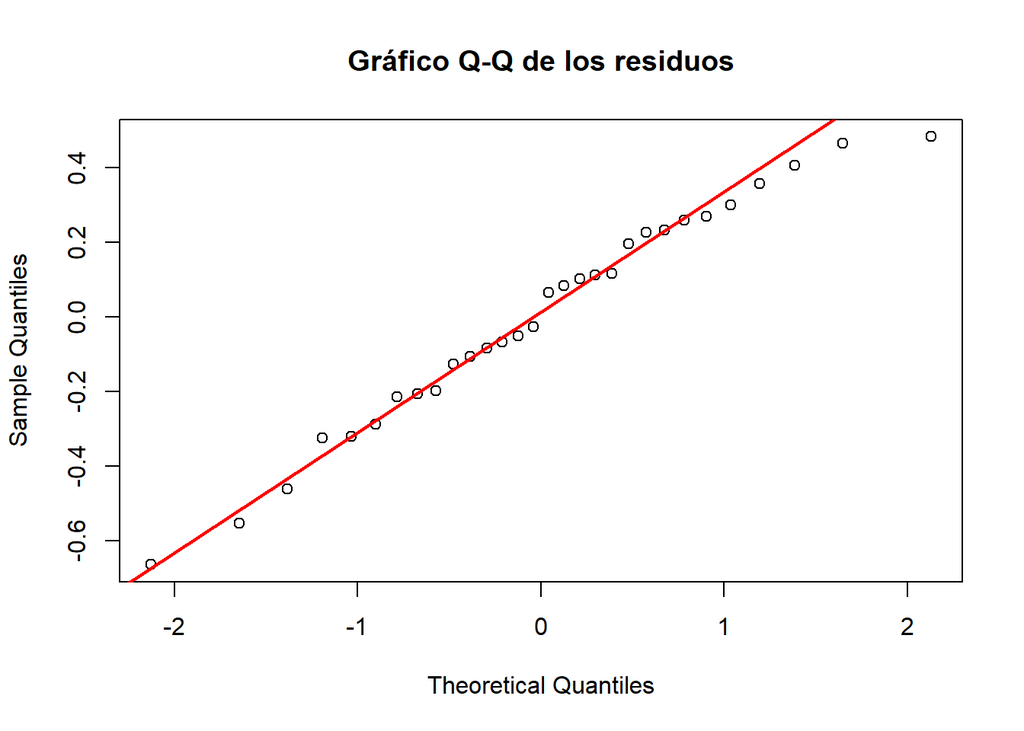

```r
qqnorm(residuals(modelo2),
       main = "Gráfico Q-Q de los residuos")
qqline(residuals(modelo2),
       col = "red",
       lwd = 2)
```

```r
#supuesto de homocedasticidad
bartlett.test(residuals(modelo2)~interaction(datos$harina, datos$fermentador))
```

```
##
##  Bartlett test of homogeneity of variances
##
## data:  residuals(modelo2) by interaction(datos$harina, datos$fermentador)
## Bartlett's K-squared = 1.8654, df = 5, p-value = 0.8674
```

NO se rechaza la hipotesis de homocedasticidad, por lo tanto, se puede asumir que las varianzas de la variable respuesta dentro de cada tratamiento son iguales.

## Analisis de varianza del modelo sin interaccion

```r
coeficientesmodelo2 <- modelo2$coefficients
coeficientesmodelo2
```

```
##             (Intercept)           bloquebloque2           bloquebloque3
##               1.5833333              -0.3333333              -0.3666667
##           bloquebloque4           bloquebloque5             harinatrigo
##              -0.1666667              -0.8500000               0.1800000
## fermentadorazucar cruda         fermentadormiel
##               0.3100000               0.1700000
```

```r
anova(modelo2)
```

```
## Analysis of Variance Table
##
## Response: incremento
##             Df Sum Sq Mean Sq F value   Pr(>F)
## bloque       4 2.4387 0.60967  5.1920 0.004232 **
## harina       1 0.2430 0.24300  2.0694 0.164354
## fermentador  2 0.4820 0.24100  2.0524 0.152311
## Residuals   22 2.5833 0.11742
## ---
## Signif. codes:  0 '***' 0.001 '**' 0.01 '*' 0.05 '.' 0.1 ' ' 1
```

Efecto de la harina

El factor harina no presenta un efecto significativo sobre el incremento (F=2.069, p=0.1644>0.05). Por lo tanto, no existe evidencia estadística suficiente para afirmar que los dos tipos de harina produzcan incrementos promedio diferentes.

Efecto del fermentador

El factor fermentador tampoco muestra un efecto significativo (F=2.052, p=0.1523>0.05). En consecuencia, no se detectan diferencias significativas entre los fermentadores respecto al incremento promedio obtenido.

## Analisis de la potencia de la prueba

```r
# Potencia post hoc para detectar diferencias entre harinas

anova_modelo2 <- anova(modelo2)

alpha <- 0.05

SS_harina <- anova_modelo2["harina", "Sum Sq"]
gl_harina <- anova_modelo2["harina", "Df"]

SSE <- anova_modelo2["Residuals", "Sum Sq"]
CMRes <- anova_modelo2["Residuals", "Mean Sq"]
gl_error <- anova_modelo2["Residuals", "Df"]

Fcrit <- qf(
  1 - alpha,
  df1 = gl_harina,
  df2 = gl_error
)

lambda <- SS_harina / CMRes

potencia_harina <- pf(
  Fcrit,
  df1 = gl_harina,
  df2 = gl_error,
  ncp = lambda,
  lower.tail = FALSE
)

eta2_parcial_harina <- SS_harina / (SS_harina + SSE)

f_cohen_harina <- sqrt(
  eta2_parcial_harina / (1 - eta2_parcial_harina)
)

resultado_potencia_harina <- data.frame(
  factor = "harina",
  gl_factor = gl_harina,
  gl_error = gl_error,
  SS_factor = SS_harina,
  CMRes = CMRes,
  F_critico = Fcrit,
  lambda = lambda,
  eta2_parcial = eta2_parcial_harina,
  f_cohen = f_cohen_harina,
  potencia = potencia_harina
)

resultado_potencia_harina
```

```
##   factor gl_factor gl_error SS_factor     CMRes F_critico   lambda eta2_parcial
## 1 harina         1       22     0.243 0.1174242   4.30095 2.069419   0.08597712
##     f_cohen  potencia
## 1 0.3066994 0.2800722
```

```r
# Potencia post hoc para detectar diferencias entre fermentadores

anova_modelo2 <- anova(modelo2)

alpha <- 0.05

SS_fermentador <- anova_modelo2["fermentador", "Sum Sq"]
gl_fermentador <- anova_modelo2["fermentador", "Df"]

SSE <- anova_modelo2["Residuals", "Sum Sq"]
CMRes <- anova_modelo2["Residuals", "Mean Sq"]
gl_error <- anova_modelo2["Residuals", "Df"]

Fcrit <- qf(
  1 - alpha,
  df1 = gl_fermentador,
  df2 = gl_error
)

lambda <- SS_fermentador / CMRes

potencia_fermentador <- pf(
  Fcrit,
  df1 = gl_fermentador,
  df2 = gl_error,
  ncp = lambda,
  lower.tail = FALSE
)

eta2_parcial_fermentador <- SS_fermentador / (SS_fermentador + SSE)

f_cohen_fermentador <- sqrt(
  eta2_parcial_fermentador / (1 - eta2_parcial_fermentador)
)

resultado_potencia_fermentador <- data.frame(
  factor = "fermentador",
  gl_factor = gl_fermentador,
  gl_error = gl_error,
  SS_factor = SS_fermentador,
  CMRes = CMRes,
  F_critico = Fcrit,
  lambda = lambda,
  eta2_parcial = eta2_parcial_fermentador,
  f_cohen = f_cohen_fermentador,
  potencia = potencia_fermentador
)

resultado_potencia_fermentador
```

```
##        factor gl_factor gl_error SS_factor     CMRes F_critico   lambda
## 1 fermentador         2       22     0.482 0.1174242  3.443357 4.104774
##   eta2_parcial   f_cohen  potencia
## 1    0.1572423 0.4319498 0.3766277
```

```r
# Potencia post hoc para detectar la interacción harina × fermentador

anova_modelo1 <- anova(modelo1)

alpha <- 0.05

SS_interaccion <- anova_modelo1["harina:fermentador", "Sum Sq"]
gl_interaccion <- anova_modelo1["harina:fermentador", "Df"]

SSE <- anova_modelo1["Residuals", "Sum Sq"]
CMRes <- anova_modelo1["Residuals", "Mean Sq"]
gl_error <- anova_modelo1["Residuals", "Df"]

Fcrit <- qf(
  1 - alpha,
  df1 = gl_interaccion,
  df2 = gl_error
)

lambda <- SS_interaccion / CMRes

potencia_interaccion <- pf(
  Fcrit,
  df1 = gl_interaccion,
  df2 = gl_error,
  ncp = lambda,
  lower.tail = FALSE
)

eta2_parcial_interaccion <- SS_interaccion /
  (SS_interaccion + SSE)

f_cohen_interaccion <- sqrt(
  eta2_parcial_interaccion /
    (1 - eta2_parcial_interaccion)
)

resultado_potencia_interaccion <- data.frame(
  factor = "harina:fermentador",
  gl_factor = gl_interaccion,
  gl_error = gl_error,
  SS_factor = SS_interaccion,
  CMRes = CMRes,
  F_critico = Fcrit,
  lambda = lambda,
  eta2_parcial = eta2_parcial_interaccion,
  f_cohen = f_cohen_interaccion,
  potencia = potencia_interaccion
)

resultado_potencia_interaccion
```

```
##               factor gl_factor gl_error SS_factor     CMRes F_critico   lambda
## 1 harina:fermentador         2       20     0.494 0.1044667  3.492828 4.728781
##   eta2_parcial f_cohen  potencia
## 1    0.1912258 0.48625 0.4216579
```

```r
#datos de la potencia juntos
rbind(
  resultado_potencia_harina,
  resultado_potencia_fermentador,
  resultado_potencia_interaccion
)
```

```
##               factor gl_factor gl_error SS_factor     CMRes F_critico   lambda
## 1             harina         1       22     0.243 0.1174242  4.300950 2.069419
## 2        fermentador         2       22     0.482 0.1174242  3.443357 4.104774
## 3 harina:fermentador         2       20     0.494 0.1044667  3.492828 4.728781
##   eta2_parcial   f_cohen  potencia
## 1   0.08597712 0.3066994 0.2800722
## 2   0.15724228 0.4319498 0.3766277
## 3   0.19122581 0.4862500 0.4216579
```

## Analisis de la eficiencia del uso de bloques

```r
#Modelo con bloques
modelo3 <- lm(incremento ~ bloque + harina * fermentador, data = datos)

#Modelo sin bloques
modelo4 <- lm(incremento ~ harina * fermentador, data = datos)

#Cuadrado medio residual
cmRESbloq <- anova(modelo3)["Residuals", "Mean Sq"]
cmRES <- anova(modelo4)["Residuals", "Mean Sq"]

#Eficiencia relativa
ER <- cmRES / cmRESbloq
ER_porcentaje <- ER * 100

ER
```

```
## [1] 1.805999
```

```r
ER_porcentaje
```

```
## [1] 180.5999
```

###Fin del proyecto Puede limpiar su entorno ejecutando el siguiente chunk

```r
rm(list = ls())
rm(list = ls())
gc()
```

```
##           used (Mb) gc trigger  (Mb) max used  (Mb)
## Ncells 1496289 80.0    2641437 141.1  2641437 141.1
## Vcells 2658527 20.3    8388608  64.0  4661048  35.6
```

```r
rm(list = ls())
cat("\014")  # Limpia la consola en RStudio
```